# How not to make a mess of it

> Programmers are always surrounded by complexity; we cannot avoid it. Our applications are complex because we are ambitious to use our computers in ever more sophisticated ways. Programming is complex because of the large number of conflicting objectives for each of our programming projects. *If our basic tool, the language in which we design and code our programs, is also complicated, the language itself becomes part of the problem rather than part of its solution.

> At first I hoped that such a technically unsound project would collapse but I soon realized it was doomed to success. Almost anything in software can be implemented, sold, and even used given enough determination. There is nothing a mere scientist can say that will stand against the flood of a hundred million dollars. But there is one quality that cannot be purchased in this way — and that is reliability. The price of reliability is the pursuit of the utmost simplicity. It is a price which the very rich find most hard to pay.

> — C.A.R. Hoare - The Emperor's Old Clothes - Turing Award Lecture (1980)

Note: remember to start recording.

# Reproducible research

> An article about computational science in a scientific publication is **not the scholarship itself**, it is merely **advertising** of the scholarship. The actual scholarship is the complete software development environment and the complete set of instructions which generated the figures.

> — Jonathan Buckheit and David Donoho, WaveLab and Reproducible Research (1995)

# Style guide

Try to avoid using the names of standard R functions for your objects, but R will generally be fairly smart about things.

```r
c <- 7
c(3, 5)
```

```
## [1] 3 5
```

```r
c
```

```
## [1] 7
```

```r
rm(c)
c
```

```
## function (..., recursive = FALSE)  .Primitive("c")
```

Try to use upperCamelCase or underscores when naming your objects (and don't mix and match). Leave periods for use in the context of S3 objects.

```r
precipExtremes <- rnorm(5)  # precip_extremes
timeInDays <- rnorm(5)  # time_in_days
summary.lm(lm(precipExtremes ~ timeInDays))
```

```
##
## Call:
## lm(formula = precipExtremes ~ timeInDays)
##
## Residuals:
##      1      2      3      4      5
## -0.351 -0.193 -0.174  0.582  0.135
##
## Coefficients:
##             Estimate Std. Error t value Pr(>|t|)
## (Intercept)  -0.0864     0.1948   -0.44     0.69
## timeInDays   -0.6651     0.6637   -1.00     0.39
##
## Residual standard error: 0.427 on 3 degrees of freedom
## Multiple R-squared:  0.251,  Adjusted R-squared:  0.00103
## F-statistic:    1 on 1 and 3 DF,  p-value: 0.39
```

- [Google's R Style Guide](http://google-styleguide.googlecode.com/svn/trunk/Rguide.xml)

# Debugging

As a scripting language, R essentially has a debugger working automatically. But there is an official debugger and other tools that greatly help in figuring out problems.

Let's briefly see these in action. I'll demo with a set of nested functions in which one has an error:

```r
fun1 <- function(x) {
    x <- x * 2
    fun2(x)
}
fun2 <- function(x) {
    fun3(x)
}
fun3 <- function(x) {
    apply(x, 1, mean)
}
```

1) We can use `debug()` to step through a function line by line

2) After an error occurs, we can use `traceback()` to look at the *call stack*

3) More helpfully, if we set `options(error = recover)` before running code, we can go into the function in which the error occurred

4) We can insert `browser()` inside a function and R will stop there and allow us to proceed with debugging statements

5) You can temporarily insert code into a function (including built-in functions) with `trace(fxnName, edit = TRUE)`

# Testing

Testing should be performed on multiple levels and begun as early as possible in the development process. For programs that accept input either from a user or file, it is important that the code validates the input is what it expects to receive. Tests that ensure individual code elements (e.g., functions, classes, and class methods) behave correctly are called \emph{unit tests}. Writing unit tests early in the process of implementing new functionality helps you think about what you want a piece of code to do, rather than just how it does it. This practice improves code quality by focusing your attention on use cases rather than getting lost in implementation details.

`RUnit` is a testing framework for R, which helps automate test setup, creation, execution, and reporting. For more information, see Bioconductor's [unit testing guidelines](http://www.bioconductor.org/developers/unitTesting-guidelines/).

# Timing your code

> premature optimization is the root of all evil

> — Donald Knuth, 1974

There are a few tools in R for timing your code.

```r
system.time(mean(rnorm(1e+07)))
```

```
##    user  system elapsed
##   0.852   0.016   0.869
```

```r
library(rbenchmark)
x <- rnorm(1e+07)
benchmark(ifelse(x < 0, x, 0), x[x < 0] <- 0, replications = 5, columns = c("replications",
    "elapsed"))
```

```
##   replications elapsed
## 1            5  10.132
## 2            5   1.252
```

# Timing your code

For more advanced assessment of bottlenecks in your code, consider `Rprof()`.

```
fun1 <- function(x) {
  res <- NULL
  n <- nrow(x)
  for (i in 1:n) if (!any(is.na(x[i,])))
    res <- rbind(res,x[i,])
  res
}

fun2 <- function(x) {
  n <- nrow(x)
  res <- matrix(0,n,ncol(x))
  k <- 1
  for (i in 1:n)
    if (!any(is.na(x[i,]))) {
      res[k,] <- x[i,]
      k <- k+1
    }
  res[1:(k-1),]
}
```

For a suitable `x` the following code snippet will create file called `profile1.out` with collected timing results.

```
Rprof("profile1.out", line.profiling=TRUE)
print(unix.time(fun1(x)))
Rprof(NULL)
```

# Memory use

You should know how much memory (RAM) the computer you are using has and keep in mind how big your objects are and how much memory you code might use. All objects in R are stored in RAM unlike, e.g., SAS or a database.

If in total, the jobs on a machine approach the physical RAM, the machine will start to use the hard disk as 'virtual memory'. This is called paging or swapping, and once this happens you're often toast.

You can assess memory use with `top` or `ps` in Linux/Mac or the Task Manager in Windows.

```r
x <- rnorm(1e+07)
object.size(x)
```

```
## 80000040 bytes
```

```r
1e+07 * 8/1e+06
```

```
## [1] 80
```

```r
print(object.size(x), units = "auto")
```

```
## 76.3 Mb
```

```r
x <- rnorm(1e+08)
gc()
```

```
##             used  (Mb) gc trigger   (Mb)  max used  (Mb)
## Ncells    179610   9.6     407500   21.8    407500  21.8
## Vcells 100835273 769.4  141716933 1081.3 110947165 846.5
```

```r
rm()
gc()
```

```
##             used  (Mb) gc trigger   (Mb)  max used  (Mb)
## Ncells    179629   9.6     407500   21.8    407500  21.8
## Vcells 100835312 769.4  148882779 1135.9 110947165 846.5
```

# Some ideas about reproducibility

- Never change a dataset manually. Always have a script that operates on the data.
- Note when and where you download, and ideally download via a script as well (e.g., wget and curl are Linux tools for automated downloading.
- Produce figures (e.g., from R) via a script and not by point-and-click
- When making figures, use *save()* or *save.image()* to save all the inputs needed to recreate a figure, with the code for making the figure in a script file
- If feasible, include your code for doing analyses and making figures in the relevant document reporting the work by using Rmarkdown or Latex with knitr or Sweave.
- Set the random number seed so someone else can duplicate your exact numbers

# Scripting

- Keep your code in script (i.e., text) files.
- Keep your files modular and focused.
- Write functions to reuse code.
- Learn a powerful, general purpose text editor

If you use a good editor (such as RStudio's built-in editor, emacs with ESS, Aquamacs, it's easier to write and understand your code.

You can then run blocks of code within RStudio easily.

To run all the code in an entire file, do `source('myCodeFile.R')`.

To run code as a background job in a Linux/Mac context: `R CMD BATCH --no-save myCodeFile.R myOutput.Rout &`

Then you don't need to leave RStudio or R or a terminal window open. Your job will run by itself. If you are logged into a remote machine, you can log out and come back later.

IMPORTANT: make sure to write any needed output to a file (e.g. .Rda files, CSV files, text output from print() or cat()).

# The UNIX command line

Being able to operate your computer from a command line rather than via point-and-click in a GUI environment provides incredible power and flexibility to the user, as well as allowing for reproducibility and automation in your work.

In Linux and Mac, you just need to open a Terminal window. On the Mac this is in Applications->Utilities->Terminal. Once in the Terminal, you can treat your Mac as if it is a UNIX machine (which it is).

Windows has the old MS-DOS command line that allows some command line functionality. There is something call *cygwin* that provides UNIX-like functionality.

# The UNIX Philosophy

> Write programs that do one thing and do it well.

> Write programs to work together.

> Write programs to handle text streams, because that is a universal interface.

— Doug McIlroy

For more details, please see:

http://en.wikipedia.org/wiki/Unix_philosophy

# Version control

The basic idea is that instead of manually trying to keep track of what changes you've made to code, data, documents, you use software to help you manage the process. This has several benefits:

- easily allowing you to go back to earlier versions
- allowing you to have multiple version you can switch between
- allowing you to share work easily without worrying about conflicts
- providing built-in backup

At a basic level, a simple principle is to have version numbers for all your work: code, datasets, manuscripts. Whenever you make a change to a dataset, increment the version number. For code and manuscripts, increment when you make substantial changes or have obvious breakpoints in your workflow.

# Version control architectures

- Client-server (e.g., CVS, Subversion)
- Distributed (e.g., Mercurial, **Git**)

# Git concepts: commit

a **snapshot** of work at a point in time

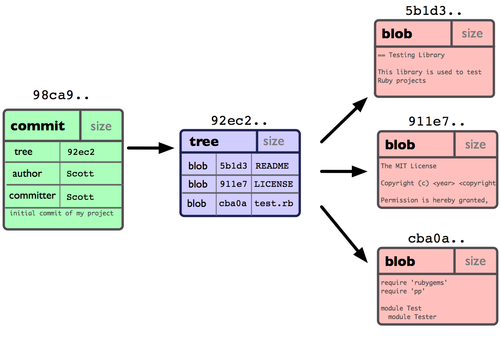

# Git concepts: repository

a group of **linked** commits (DAG)

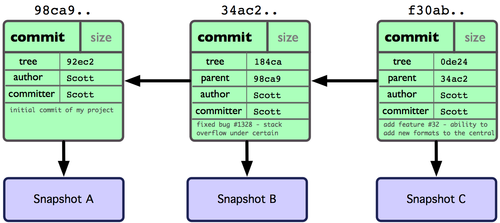

# Git concepts: hash

toy “implementation”

```r
library("digest")

# first commit
data1 <- "This is the start of my paper2."
meta1 <- "date: 8/20/13"
hash1 <- digest(c(data1, meta1), algo = "sha1")
cat("Hash:", hash1)
```

```
## Hash: 32cff5042299244c8c248f6804bb9756912e5492
```

```r
# second commit, linked to the first
data2 <- "Some more text in my paper..."
meta2 <- "date: 8/20/13"
# Note we add the parent hash here!
hash2 <- digest(c(data2, meta2, hash1), algo = "sha1")
cat("Hash:", hash2)
```

```
## Hash: 43925778805d33de28aba5697a967f04613f9153
```

# Stage 1: Local, single-user, linear workflow

Simply type `git` (or `git help`) to see a full list of all the 'core' commands. We'll now go through most of these via small practical exercises:

```bash
git help
```

```
## usage: git [--version] [--exec-path[=<path>]] [--html-path] [--man-path] [--info-path]
##            [-p|--paginate|--no-pager] [--no-replace-objects] [--bare]
##            [--git-dir=<path>] [--work-tree=<path>] [--namespace=<name>]
##            [-c name=value] [--help]
##            <command> [<args>]
##
## The most commonly used git commands are:
##    add        Add file contents to the index
##    bisect     Find by binary search the change that introduced a bug
##    branch     List, create, or delete branches
##    checkout   Checkout a branch or paths to the working tree
##    clone      Clone a repository into a new directory
##    commit     Record changes to the repository
##    diff       Show changes between commits, commit and working tree, etc
##    fetch      Download objects and refs from another repository
##    grep       Print lines matching a pattern
##    init       Create an empty git repository or reinitialize an existing one
##    log        Show commit logs
##    merge      Join two or more development histories together
##    mv         Move or rename a file, a directory, or a symlink
##    pull       Fetch from and merge with another repository or a local branch
##    push       Update remote refs along with associated objects
##    rebase     Forward-port local commits to the updated upstream head
##    reset      Reset current HEAD to the specified state
##    rm         Remove files from the working tree and from the index
##    show       Show various types of objects
##    status     Show the working tree status
##    tag        Create, list, delete or verify a tag object signed with GPG
##
## See 'git help <command>' for more information on a specific command.
```

# `git init`: create an empty repository

```bash
cd ~/src
rm -rf jm-git-demo
git init jm-git-demo
```

```
## Initialized empty Git repository in /accounts/gen/vis/paciorek/src/jm-git-demo/.git/
```

Let's look at what git did:

```bash
cd ~/src/jm-git-demo
ls -la
```

```
## total 3
## drwxr-sr-x 3 paciorek scfstaff  3 Aug 26 12:21 .
## drwxr-sr-x 3 paciorek scfstaff  3 Aug 26 12:21 ..
## drwxr-sr-x 7 paciorek scfstaff 10 Aug 26  2013 .git
```

```bash
cd ~/src/jm-git-demo
ls -l .git
```

```
## total 4
## drwxr-sr-x 2 paciorek scfstaff  2 Aug 26 12:21 branches
## -rw-r--r-- 1 paciorek scfstaff 92 Aug 26 12:21 config
## -rw-r--r-- 1 paciorek scfstaff 73 Aug 26 12:21 description
## -rw-r--r-- 1 paciorek scfstaff 23 Aug 26 12:21 HEAD
## drwxr-sr-x 2 paciorek scfstaff 10 Aug 26 12:21 hooks
## drwxr-sr-x 2 paciorek scfstaff  3 Aug 26 12:21 info
## drwxr-sr-x 4 paciorek scfstaff  4 Aug 26  2013 objects
## drwxr-sr-x 4 paciorek scfstaff  4 Aug 26 12:21 refs
```

# `git add`: adding content to the repository

Now let's edit our first file in the test directory with a text editor… I'm doing it programatically here for automation purposes, but you'd normally be editing by hand

```bash
cd ~/src/jm-git-demo
echo "My first bit of text" > file1.txt
```

Now we can tell git about this new file using the `add` command:

```bash
cd ~/src/jm-git-demo
git add file1.txt
```

We can now ask git about what happened with `status`:

```bash
cd ~/src/jm-git-demo
git status
```

```
## # On branch master
## #
## # Initial commit
## #
## # Changes to be committed:
## #   (use "git rm --cached <file>..." to unstage)
## #
## #    new file:   file1.txt
## #
```

# `git commit`: permanently record our changes in git's database

```bash
cd ~/src/jm-git-demo
git commit -a -m"This is our first commit"
```

```
## [master (root-commit) efa304a] This is our first commit
##  Committer: Christopher Paciorek <paciorek@scf.Berkeley.EDU>
## Your name and email address were configured automatically based
## on your username and hostname. Please check that they are accurate.
## You can suppress this message by setting them explicitly:
##
##     git config --global user.name "Your Name"
##     git config --global user.email you@example.com
##
## After doing this, you may fix the identity used for this commit with:
##
##     git commit --amend --reset-author
##
##  1 file changed, 1 insertion(+)
##  create mode 100644 file1.txt
```

# `git log`: what has been committed so far

```bash
cd ~/src/jm-git-demo
git log
```

```
## commit efa304a2af32a78a231c6555add534077ab2cae7
## Author: Christopher Paciorek <paciorek@scf.Berkeley.EDU>
## Date:   Mon Aug 26 12:21:59 2013 -0700
##
##     This is our first commit
```

# `git diff`: what have I changed?

Let's do a little bit more work… Again, in practice you'll be editing the files by hand, here we do it via shell commands for the sake of automation (and therefore the reproducibility of this tutorial!)

```bash
cd ~/src/jm-git-demo
echo "And now some more text..." >> file1.txt
```

And now we can ask git what is different:

```bash
cd ~/src/jm-git-demo
git diff
```

```
## diff --git a/file1.txt b/file1.txt
## index ce645c7..4baa979 100644
## --- a/file1.txt
## +++ b/file1.txt
## @@ -1 +1,2 @@
##  My first bit of text
## +And now some more text...
```

# The cycle of git virtue: work, commit, work, commit, …

```bash
cd ~/src/jm-git-demo
git commit -a -m"I have made great progress on this critical matter."
```

```
## [master 6b06d8f] I have made great progress on this critical matter.
##  Committer: Christopher Paciorek <paciorek@scf.Berkeley.EDU>
## Your name and email address were configured automatically based
## on your username and hostname. Please check that they are accurate.
## You can suppress this message by setting them explicitly:
##
##     git config --global user.name "Your Name"
##     git config --global user.email you@example.com
##
## After doing this, you may fix the identity used for this commit with:
##
##     git commit --amend --reset-author
##
##  1 file changed, 1 insertion(+)
```

- `git log` revisited

First, let's see what the log shows us now:

```bash
cd ~/src/jm-git-demo
git log
```

```
## commit 6b06d8f5772b0a6f462399d74e5b79ccb4591ed9
## Author: Christopher Paciorek <paciorek@scf.Berkeley.EDU>
## Date:   Mon Aug 26 12:21:59 2013 -0700
##
##     I have made great progress on this critical matter.
##
## commit efa304a2af32a78a231c6555add534077ab2cae7
## Author: Christopher Paciorek <paciorek@scf.Berkeley.EDU>
## Date:   Mon Aug 26 12:21:59 2013 -0700
##
##     This is our first commit
```

Sometimes it's handy to see a very summarized version of the log:

```bash
cd ~/src/jm-git-demo
git log --oneline --topo-order --graph
```

```
## * 6b06d8f I have made great progress on this critical matter.
## * efa304a This is our first commit
```

Git supports *aliases:* new names given to command combinations. Let's make this handy shortlog an alias, so we only have to type `git slog` and see this compact log:

```bash
cd ~/src/jm-git-demo
# We create our alias (this saves it in git's permanent configuration file):
git config --global alias.slog "log --oneline --topo-order --graph"
# And now we can use it
git slog
```

```
## * 6b06d8f I have made great progress on this critical matter.
## * efa304a This is our first commit
```

# `git mv` and `rm`: moving and removing files

While `git add` is used to add fils to the list git tracks, we must also tell it if we want their names to change or for it to stop tracking them. In familiar Unix fashion, the `mv` and `rm` git commands do precisely this:

```bash
cd ~/src/jm-git-demo
git mv file1.txt file-newname.txt
git status
```

```
## # On branch master
## # Changes to be committed:
## #   (use "git reset HEAD <file>..." to unstage)
## #
## #    renamed:    file1.txt -> file-newname.txt
## #
```

Note that these changes must be committed too, to become permanent! In git's world, until something hasn't been committed, it isn't permanently recorded anywhere.

```bash
cd ~/src/jm-git-demo
git commit -a -m"I like this new name better"
echo "Let's look at the log again:"
git slog
```

```
## [master b93ee25] I like this new name better
##  Committer: Christopher Paciorek <paciorek@scf.Berkeley.EDU>
## Your name and email address were configured automatically based
## on your username and hostname. Please check that they are accurate.
## You can suppress this message by setting them explicitly:
##
##     git config --global user.name "Your Name"
##     git config --global user.email you@example.com
##
## After doing this, you may fix the identity used for this commit with:
##
##     git commit --amend --reset-author
##
##  1 file changed, 0 insertions(+), 0 deletions(-)
##  rename file1.txt => file-newname.txt (100%)
## Let's look at the log again:
## * b93ee25 I like this new name better
## * 6b06d8f I have made great progress on this critical matter.
## * efa304a This is our first commit
```

And `git rm` works in a similar fashion.

**Optional:** Exercise

Add a new file `file2.txt`, commit it, make some changes to it, commit them again, and then remove it (and don't forget to commit this last step!).

# Local user, branching: the concept

What is a branch? Simply a *label for the 'current' commit in a sequence of ongoing commits*:

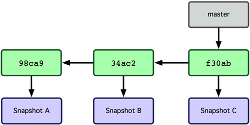

There can be multiple branches alive at any point in time; the working directory is the state of a special pointer called HEAD. In this example there are two branches, *master* and *testing*, and *testing* is the currently active branch since it's what HEAD points to:

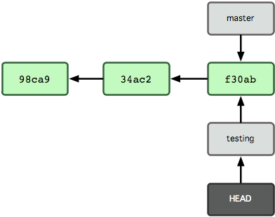

Once new commits are made on a branch, HEAD and the branch label move with the new commits:

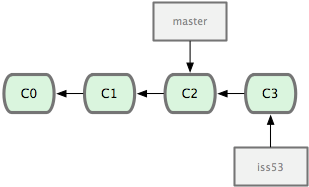

This allows the history of both branches to diverge:

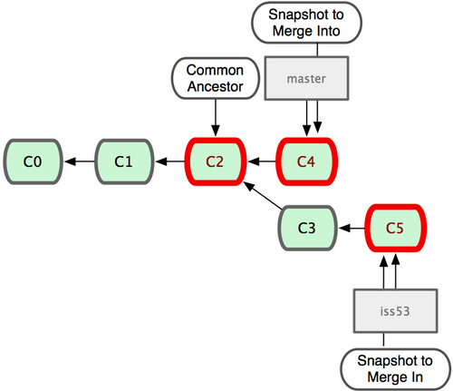

But based on this graph structure, git can compute the necessary information to merge the divergent branches back and continue with a unified line of development:

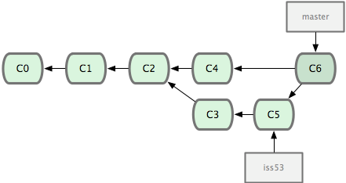

# Local user, branching: an example

Let's now illustrate all of this with a concrete example. Let's get our bearings first:

```bash
cd ~/src/jm-git-demo
git status
ls
```

```
## # On branch master
## nothing to commit (working directory clean)
## file-newname.txt
```

We are now going to try two different routes of development: on the `master` branch we will add one file and on the `experiment` branch, which we will create, we will add a different one. We will then merge the experimental branch into `master`.

```bash
cd ~/src/jm-git-demo
git branch experiment
git checkout experiment
```

```bash
cd ~/src/jm-git-demo
echo "Some crazy idea" > experiment.txt
git add experiment.txt
git commit -a -m"Trying something new"
git slog
```

```
## [experiment 58deeb0] Trying something new
##  Committer: Christopher Paciorek <paciorek@scf.Berkeley.EDU>
## Your name and email address were configured automatically based
## on your username and hostname. Please check that they are accurate.
## You can suppress this message by setting them explicitly:
##
##     git config --global user.name "Your Name"
##     git config --global user.email you@example.com
##
## After doing this, you may fix the identity used for this commit with:
##
##     git commit --amend --reset-author
##
##  1 file changed, 1 insertion(+)
##  create mode 100644 experiment.txt
## * 58deeb0 Trying something new
## * b93ee25 I like this new name better
## * 6b06d8f I have made great progress on this critical matter.
## * efa304a This is our first commit
```

```bash
cd ~/src/jm-git-demo
git checkout master
git slog
```

```
## * b93ee25 I like this new name better
## * 6b06d8f I have made great progress on this critical matter.
## * efa304a This is our first commit
```

```bash
cd ~/src/jm-git-demo
echo "All the while, more work goes on in master..." >> file-newname.txt
git commit -a -m"The mainline keeps moving"
git slog
```

```
## [master c622b2f] The mainline keeps moving
##  Committer: Christopher Paciorek <paciorek@scf.Berkeley.EDU>
## Your name and email address were configured automatically based
## on your username and hostname. Please check that they are accurate.
## You can suppress this message by setting them explicitly:
##
##     git config --global user.name "Your Name"
##     git config --global user.email you@example.com
##
## After doing this, you may fix the identity used for this commit with:
##
##     git commit --amend --reset-author
##
##  1 file changed, 1 insertion(+)
## * c622b2f The mainline keeps moving
## * b93ee25 I like this new name better
## * 6b06d8f I have made great progress on this critical matter.
## * efa304a This is our first commit
```

```bash
cd ~/src/jm-git-demo
ls
```

```
## file-newname.txt
```

```bash
cd ~/src/jm-git-demo
git merge experiment
git slog
```

```
## Merge made by the 'recursive' strategy.
##  experiment.txt |    1 +
##  1 file changed, 1 insertion(+)
##  create mode 100644 experiment.txt
## *   e7c51ae Merge branch 'experiment'
## |\
## | * 58deeb0 Trying something new
## * | c622b2f The mainline keeps moving
## |/
## * b93ee25 I like this new name better
## * 6b06d8f I have made great progress on this critical matter.
## * efa304a This is our first commit
```

# Using remotes as a single user

We are now going to introduce the concept of a *remote repository*: a pointer to another copy of the repository that lives on a different location. This can be simply a different path on the filesystem or a server on the internet.

For this discussion, we'll be using remotes hosted on the [GitHub.com](http://github.com) service, but you can equally use other services like [BitBucket](http://bitbucket.org) or [Gitorious](http://gitorious.org) as well as host your own.

```bash
cd ~/src/jm-git-demo
ls
echo "Let's see if we have any remote repositories here:"
git remote -v
```

```
## experiment.txt
## file-newname.txt
## Let's see if we have any remote repositories here:
```

Since the above cell didn't produce any output after the `git remote -v` call, it means we have no remote repositories configured. We will now proceed to do so. Once logged into GitHub, go to the [new repository page](https://github.com/new) and make a repository called `test`. Do **not** check the box that says `Initialize this repository with a README`, since we already have an existing repository here. That option is useful when you're starting first at Github and don't have a repo made already on a local computer.

We can now follow the instructions from the next page:

```bash
cd ~/src/jm-git-demo
git remote add origin git@github.com:jarrodmillman/test.git
git push -u origin master
```

Let's see the remote situation again:

```bash
cd ~/src/jm-git-demo
git remote -v
```

```
## origin   git@github.com:jarrodmillman/test.git (fetch)
## origin   git@github.com:jarrodmillman/test.git (push)
```

We can now [see this repository publicly on github](https://github.com/jarrodmillman/test).

Let's see how this can be useful for backup and syncing work between two different computers. I'll simulate a 2nd computer by working in a different directory…

```bash
cd ~/src/
# Here I clone my 'test' repo but with a different name, test2, to simulate a 2nd computer
git clone git@github.com:jarrodmillman/test.git test2
cd test2
pwd
git remote -v
```

[output not shown]

Let's now make some changes in one 'computer' and synchronize them on the second.

```bash
cd ~/src/test2  # working on computer #2
echo "More new content on my experiment" >> experiment.txt
git commit -a -m"More work, on machine #2"
```

[output not shown]

Now we put this new work up on the github server so it's available from the internet

```bash
cd ~/src/test2  # working on computer #2
git push
```

Now let's fetch that work from machine #1:

```bash
cd ~/src/jm-git-demo
git pull
```

# An important aside: conflict management

While git is very good at merging, if two different branches modify the same file in the same location, it simply can't decide which change should prevail. At that point, human intervention is necessary to make the decision. Git will help you by marking the location in the file that has a problem, but it's up to you to resolve the conflict. Let's see how that works by intentionally creating a conflict.

We start by creating a branch and making a change to our experiment file:

```bash
cd ~/src/jm-git-demo
git branch trouble
git checkout trouble
echo "This is going to be a problem..." >> experiment.txt
git commit -a -m"Changes in the trouble branch"
```

```
## [trouble 6f138f9] Changes in the trouble branch
##  Committer: Christopher Paciorek <paciorek@scf.Berkeley.EDU>
## Your name and email address were configured automatically based
## on your username and hostname. Please check that they are accurate.
## You can suppress this message by setting them explicitly:
##
##     git config --global user.name "Your Name"
##     git config --global user.email you@example.com
##
## After doing this, you may fix the identity used for this commit with:
##
##     git commit --amend --reset-author
##
##  1 file changed, 1 insertion(+)
```

And now we go back to the master branch, where we change the *same* file:

```bash
cd ~/src/jm-git-demo
git checkout master
echo "More work on the master branch..." >> experiment.txt
git commit -a -m"Mainline work"
```

```
## [master 0ee59f4] Mainline work
##  Committer: Christopher Paciorek <paciorek@scf.Berkeley.EDU>
## Your name and email address were configured automatically based
## on your username and hostname. Please check that they are accurate.
## You can suppress this message by setting them explicitly:
##
##     git config --global user.name "Your Name"
##     git config --global user.email you@example.com
##
## After doing this, you may fix the identity used for this commit with:
##
##     git commit --amend --reset-author
##
##  1 file changed, 1 insertion(+)
```

So now let's see what happens if we try to merge the `trouble` branch into `master`:

```bash
cd ~/src/jm-git-demo
git merge trouble
```

```
## Auto-merging experiment.txt
## CONFLICT (content): Merge conflict in experiment.txt
## Automatic merge failed; fix conflicts and then commit the result.
```

Let's see what git has put into our file:

```bash
cd ~/src/jm-git-demo
cat experiment.txt
```

```
## Some crazy idea
## <<<<<<< HEAD
## More work on the master branch...
## =======
## This is going to be a problem...
## >>>>>>> trouble
```

At this point, we go into the file with a text editor, decide which changes to keep, and make a new commit that records our decision. To automate my edits, I use the `sed` command.

```bash
cd ~/src/jm-git-demo
sed -i '/^</d' experiment.txt
sed -i '/^>/d' experiment.txt
sed -i '/^=/d' experiment.txt
```

I've now made the edits, in this case I decided that both pieces of text were useful, so I just accepted both additions.

```bash
cd ~/src/jm-git-demo
cat experiment.txt
```

```
## Some crazy idea
## More work on the master branch...
## This is going to be a problem...
```

Let's then make our new commit:

```bash
cd ~/src/jm-git-demo
git commit -a -m"Completed merge of trouble, fixing conflicts along the way"
git slog
```

```
## [master 209bdbc] Completed merge of trouble, fixing conflicts along the way
##  Committer: Christopher Paciorek <paciorek@scf.Berkeley.EDU>
## Your name and email address were configured automatically based
## on your username and hostname. Please check that they are accurate.
## You can suppress this message by setting them explicitly:
##
##     git config --global user.name "Your Name"
##     git config --global user.email you@example.com
##
## After doing this, you may fix the identity used for this commit with:
##
##     git commit --amend --reset-author
##
## *   209bdbc Completed merge of trouble, fixing conflicts along the way
## |\
## | * 6f138f9 Changes in the trouble branch
## * | 0ee59f4 Mainline work
## |/
## *   e7c51ae Merge branch 'experiment'
## |\
## | * 58deeb0 Trying something new
## * | c622b2f The mainline keeps moving
## |/
## * b93ee25 I like this new name better
## * 6b06d8f I have made great progress on this critical matter.
## * efa304a This is our first commit
```

*Note:* While it's a good idea to understand the basics of fixing merge conflicts by hand, in some cases you may find the use of an automated tool useful. Git supports multiple [merge tools](https://www.kernel.org/pub/software/scm/git/docs/git-mergetool.html): a merge tool is a piece of software that conforms to a basic interface and knows how to merge two files into a new one. Since these are typically graphical tools, there are various to choose from for the different operating systems, and as long as they obey a basic command structure, git can work with any of them.

# Collaborating on github with a small team

Single remote with shared access: we are going to set up a shared collaboration with one partner (the person sitting next to you). This will show the basic workflow of collaborating on a project with a small team where everyone has write privileges to the same repository.

Note for SVN users: this is similar to the classic SVN workflow, with the distinction that commit and push are separate steps. SVN, having no local repository, commits directly to the shared central resource, so to a first approximation you can think of `svn commit` as being synonymous with

[output not shown]

We will have two people, let's call them Alice and Bob, sharing a repository. Alice will be the owner of the repo and she will give Bob write privileges.

We begin with a simple synchronization example, much like we just did above, but now between *two people* instead of one person. Otherwise it's the same:

- Bob clones Alice's repository.
- Bob makes changes to a file and commits them locally.
- Bob pushes his changes to github.
- Alice pulls Bob's changes into her own repository.

Next, we will have both parties make non-conflicting changes each, and commit them locally. Then both try to push their changes:

- Alice adds a new file, `alice.txt` to the repo and commits.
- Bob adds `bob.txt` and commits.
- Alice pushes to github.
- Bob tries to push to github. What happens here?

The problem is that Bob's changes create a commit that conflicts with Alice's, so git refuses to apply them. It forces Bob to first do the merge on his machine, so that if there is a conflict in the merge, Bob deals with the conflict manually (git could try to do the merge on the server, but in that case if there's a conflict, the server repo would be left in a conflicted state without a human to fix things up). The solution is for Bob to first pull the changes (pull in git is really fetch+merge), and then push again.

# Learning Git

- [Git for Scientists: A Tutorial](http://nyuccl.org/pages/GitTutorial/)
- [Gitwash: workflow for scientific Python projects](http://matthew-brett.github.io/pydagogue/gitwash_build.html)
- [Git branching demo](http://pcottle.github.io/learnGitBranching/)

# Code review

[figure not shown]

# knitr

[figure not shown]

> Instead of imagining that our main task is to instruct a computer what to do, let us concentrate rather on explaining to human beings what we want a computer to do.

> — Donald Knuth, Literate programming (1984)

# Makefile

Make is a popular tool for process automation. It has a declarative syntax for expressing dependencies between sources and targets and a simple (timestamp-based) mechanism for resolving when dependencies need to be rebuilt.

Here is a simplified example taken from the build system for the slides for this bootcamp:

```bash
clean:
        rm -rf *.md *.html


%.md: %.Rmd
        ./make_slides $(basename $(@))
```

# Implementing Reproducible Computational Research

[figure not shown]

# Best practices

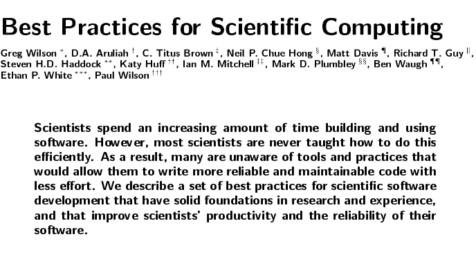

# Don't just “make the dirt fly!”

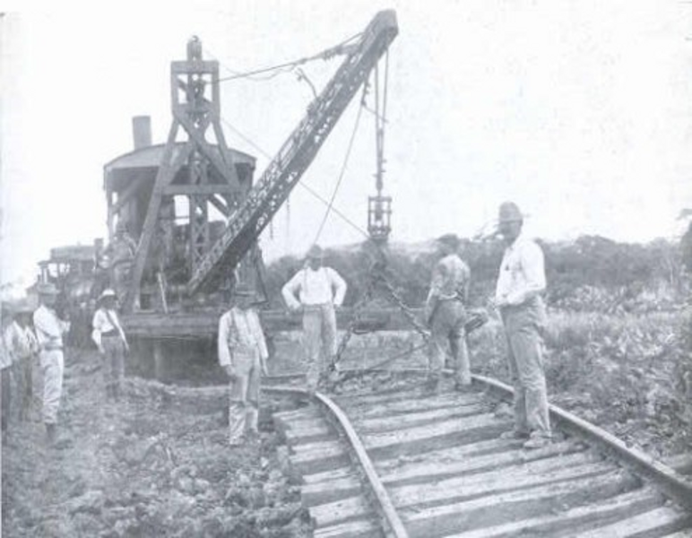

# Breakout

1. Configure Git for use at the commandline (see next slide).
2. Clone practice problem:

   ```bash
   cd <where you want to work>
   git clone https://github.com/berkeley-scf/r-bootcamp-2013.git
   ```

3. Debug `fun3` in `r-bootcamp-2013/modules/src/profile-example.R`.
4. Profile and interpret results.

# Breakout: configure Git

The minimal amount of configuration for git to work without pestering you is to tell it who you are:

```bash
git config --global user.name "Jarrod Millman"
git config --global user.email "millman@berkeley.edu"
```

And how you will edit text files (it will often ask you to edit messages and other information, and thus wants to know how you like to edit your files):

```bash
# Put here your preferred editor. If this is not set, git will honor
# the $EDITOR environment variable
git config --global core.editor /usr/bin/jed  # a lightweight unix editor

# On Windows Notepad will do in a pinch, I recommend Notepad++ as a free alternative
# On the mac, you can set nano or emacs as a basic option

# And while we're at it, we also turn on the use of color, which is very useful
git config --global color.ui "auto"
```